# Fixed Income Analysis -- Auction Volume Flows

I will further examine fixed income ratios after combining the entire curve. THe products I look at are 2Y, ZT, 3Y, ZF, 5Y, 7Y, ZN, 10Y, ZB, UB, and 30Y. My data is from 1/1/2011 to 10/31/2016. Below is a step-by-step process of the data analysis on auction volume that I took. This has been edited to reflect notes sent by Chris Fort on 11/7/2016.

In the first section (probably took the longest), I grabbed data then cleaned it. I spent a lot of thought on proper standardizing techniques.

In the second section, I model product ratios with auction data and find some interesting (or odd) results. I focus on the hour after the auction, two hours, and four hours after the auction. I run a normal multivariate regression to capture this information.

The third section holds my conclusions and trading implications.

```python
import os
#os.chdir('C:\\Users\\eirc\\Dropbox\\Code\\Python Code')
import pandas as pd
import numpy as np
import matplotlib.pyplot as plt
%matplotlib inline
import itertools
import pickle
import helper
from sklearn import linear_model, decomposition, preprocessing
from scipy import stats
```

# 1 Data Wrangling

Fixed income auctions are a subset of the Dutch auction, where people bid and everyone gets the same price. I got events data from FX Street and group the auctions by product. In this chapter, I lay out the issues in the raw data and steps I took to clean volume and auction data. In addition, there is some basic exploratory data analysis and I discuss the implications of using ratios versus other techniques.

## 1.1 Volume Data Wrangling -- Standardizing

I further standardize by contract size. The cash all have 1 million dollar notional amounts while the futures have 100k amounts (besides ZT which has 200k). This means that futures should trade 10 times more to equal the same notional amount as cash. So, I divide all future volumes by 10, besides ZT which I divide by 5 to normalize for contract size. This brings some decimals for the futures which is inaccurate, but since I am mainly focused on volume ratios, this point is moot.

I thought about rolling the data, but after weighing the pros and cons of a intraday roll versus a longer term roll, there was no decisive winner, so I have not added rolling yet. The intraday roll would allow me to take advantage of the quick bursts and further standardize to the day. On Brexit for instance, volatility was exceedingly high and if I created an intraday roll it would help me discern the 'true' volume spikes that day. A longer period roll also has merit, because volume is seasonal and will trade more for an extended period of time sometimes. (Perhaps the solution is to create a double roll, one intraday and one longer term.)

```python
volume=pd.read_csv(r'C:\Users\eirc\Dropbox\Data\volume_full.csv',index_col=0,parse_dates=True)
volume[['ZT']]=volume[['ZT']]/5
volume[['ZF','ZN','ZB','UB']]=volume[['ZF','ZN','ZB','UB']]/10
vol_hour=volume.resample('1H').sum().dropna(how='all')
```

## 1.2 Volume Data Wrangling -- Issues

The goal of this project is to find volume relationships between the various products during auctions. The instructions explicitly said to use ratio's; I believe this will be an accurate representation of how a product volume interacts with the other product volumes. This is a very effective standardization technique, but there are a few major issues.

1. Spurious false data
2. Missing values
3. Throwing away a product

Missing values will break the ratios, because it is not possible to divide by nan or 0. In addition, including a ratio has the potential of creating synthetic false data points (imagine using UB which randomly spikes -- then I am not sure if the data point is a larger curve move or if it is just UB). Below I will use a few standardizing techniques to remove these potential issues.

```python
#volume percent calculations
vol_perc=vol_hour.div(vol_hour.sum(axis=1),axis='rows') #ovlume percents
vol_grouped=vol_perc.groupby(lambda x: x.hour)
#vol_grouped.mean().plot().legend(loc='center left',bbox_to_anchor=(1.0,0.5))
```

## 1.3 Volume Data Wrangling -- Issue Fixes

#### 1.3.1.1 Spurious False Data -- Correlations

One way to look for spurious data is correlations; correlations explain relationships between products and if the volume ratio correlations deviate from the volume correlations by too much, there is probably some bogus synthetic data being used (imagine using UB which randomly spikes -- then I am not sure if the data point is a larger curve move or if it is just UB). For example, to make sure a ZN based move is actually a ZN based move I can look at correlations between the original volume data set and my new ratio data set. A correlation matrix will tell me the relationship between all the products and I want those relationships to remain similar when I add in ratio data. Thus, I compute two separate correlation matrices: one with original values and one with the ratios. To measure similarity, I use L1 and L2 matrix distance tests to see which ratio creates the most closest correlations. Suppose matrix $A=(a_{ij})$ and $B=(b_{ij})$, then to get the distances the following equations are used:

\begin{equation} L_1(\mathbf{A}, \mathbf{B}) = \sum_{i=1}^n \sum_{j=1}^n |a_{ij} - b_{ij}| \end{equation}\begin{equation} L_2(\mathbf{A}, \mathbf{B}) = \sqrt{\sum_{i=1}^n \sum_{j=1}^n (a_{ij} - b_{ij})^2} \end{equation}

Thus the smaller the values are the closer to the original volumes and do not have the baseline ratio creating funky data. I have upsampled the volume to one hour which is the minimum time frame analysis I use in my tests.

```python
products=['ZT','ZF','ZN','ZB','UB','2Y','3Y','5Y','7Y','10Y','30Y']
ratio_search=pd.DataFrame(index=products,columns=['L1','L2'])
for i in range(len(products)):
    base_vol=vol_hour.corr().drop(products[i],axis=1).drop(products[i])
    ratios=vol_hour.div(vol_hour[products[i]],axis='index')
    ratios.drop(products[i],axis=1,inplace=True)
    ratios=ratios.apply(helper.zscore_norm)
    ratios_cor=ratios.corr()
    ratio_search.ix[i,'L1']=helper.cor_search(base_vol,ratios_cor,L1=True)
    ratio_search.ix[i,'L2']=helper.cor_search(base_vol,ratios_cor,L1=False)
print(ratio_search)
```

```
          L1        L2
ZT   13.0843   1.53927
ZF    42.745   4.79908
ZN   34.4267    4.0249
ZB    35.785    4.0431
UB   13.4195   1.66321
2Y   3.94666  0.561485
3Y   14.7552   1.85565
5Y   43.3917   4.75342
7Y   26.7505   3.02643
10Y  36.1354   4.36859
30Y  29.1015   3.41885
```

#### 1.3.1.2 Spurious False Data -- Skews

Another aspect that can create false data points is skew. In addition to correlations, I must also look at how the skew of each baseline product, so that it does not influence the ratios in a more extreme fashion. Below I plot the distributions of two graphs ZN and ZT. ZN's volumes are more evenly distributed whereas ZT's have a much larger left tail spike. This could lead to potential troubles when using ZT. If ZT has a bunch of low volumes that means the volume ratio is very high, but if it suddenly spikes, the volume ratio will be very low and the change will be solely attributed to ZT even though I will not be able to tell. ZN does not have as many low volumes so it is less prone to these large volume ratio changes.

```
2Y     2.762631
3Y     2.428643
5Y     2.224983
7Y     2.298029
10Y    2.059569
30Y    1.832948
ZT     2.974707
ZF     3.152145
ZN     2.706379
ZB     2.432990
UB     2.264642
Name: Skew, dtype: float64
```

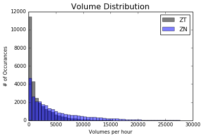

```python
searching=pd.concat([vol_hour.skew(),vol_hour.isnull().sum()],axis=1)
searching.columns=['Skew','Missing']
print(searching.ix[:,0])
bins=np.linspace(0,30000,52)
plt.hist(vol_hour['ZT'].dropna(how='all'),bins,alpha=0.5,label='ZT',color='k')
plt.hist(vol_hour['ZN'].dropna(how='all'),bins,alpha=0.5,label='ZN',color='b')
plt.legend(loc='upper right')
plt.title('Volume Distribution',fontsize=16)
plt.ylabel('# of Occurances')
plt.xlabel('Volumes per hour')
plt.show()
```

### 1.3.2 Missing Data

My second issue that I raised with the volume ratios are missing values. If I choose a base that has too many missing values, I am just throwing some of my ratio data away which is also bad. The cash bonds all have large amounts of missing values compared to the futures, which strongly hints that I should use a futures product as a baseline ratio. Even within the futures ZF, ZB, and ZN have a lot less missing values than ZT and UB.

```python
print(searching.ix[:,1])
```

```
2Y     1664
3Y      811
5Y      174
7Y      336
10Y     172
30Y     304
ZT      124
ZF       13
ZN       13
ZB       14
UB      251
Name: Missing, dtype: int64
```

### 1.3.3 Throwing Away a Product

There is no way around throwing away a product. If I use ZB as the baseline, I will not have any information about ZB; ZB volume would be imbedded in each of my other volume ratios. I accept that I have to throw away a product and move on.

### 1.3.4 Volume Data Cleaning Conclusion

In the end, I use missing data as my first cut and choose between ZF, ZN, and ZB because they have the least amount of missing values (by a large magnitude). Then among these three I use my correlation matching test and ZN has both the smallest L1 and L2 distance. In addition, it has a lot less skew that ZF and is comparable in skew to ZB. Thus, I use ZN as my baseline ratio, which should minimize both the spurious false data issue and the missing data issue. In addition, I use z-scores to further standardize my ratios. Z-scores will allow me to compare the current product volume ratio to previous product volume ratios as well as give create normal (mean=0, standard deviation=1) ratios.

```python
ratios_hour=vol_hour.div(vol_hour.ZN,axis='index') #create volume ratios with ZN as baseline
ratios_hour.drop('ZN',axis=1,inplace=True)
ratios_hour.columns=[ticker+'/ZN' for ticker in ratios_hour.columns]
ratios_hour=ratios_hour.fillna(0)
```

## 1.4 Auction Data Wrangling -- Standardizing

The second part of my data aside from the volume ratios is my auction data. Here I parse Bloomberg for all treasury auctions from 2010 to 2016 for around 420 auctions or 70 for each product. (I am limited in my data by Gtick data, not Bloomberg data. I can go much further back than 2010 for Bloomberg auction data.) Each auction comes with an interesting cross-section of data: coupon, amount sold, non-competitive bid %, Bid/Cover, High-Yield %, primary dealer % and indirect bidder %. Each one of these data points sheds some more light on the auction, although some admittedly are more interesting than others. Below, I clean and parse the data for exploratory relationships.

```python
#open auction data
with open(r'C:\Users\eirc\Dropbox\Data\auction', 'rb') as f:
    auctions=pickle.load(f, encoding='latin1')
#put in dataframe
auction_data=pd.DataFrame() #store auction data
auction_products=s=['Five','Seven','Three','Ten','Thirty','Two']
for key in auction_products: #add in key string
    auctions[key]['Product']=key
    auction_data=auction_data.append(auctions[key])
```

### 1.4.1 Autocorrelation

Just like the volume data, the auction data is not clean. Some of the variables exhibit extreme autocorrelation; Coupons and High-Yield % should not be expected to be constant across time, the coupon today will be close to the coupon a month prior. Below, I show this point graphically: I plot the High-Yield % across the entire dataset. I can get rid of this non-stationarity by first-differencing. Below I show two plots both of high-yield %, one is the normal data and the other is the transformed version. I first-difference the two variables with significant autocorrelation: Coupon and high-yield %. It is clear that first-differencing has removed the problem with autocorrelation.

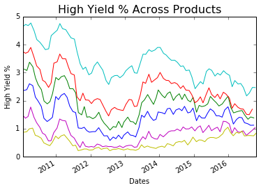

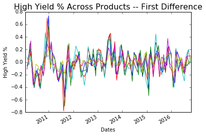

```python
auction_trans=auction_data.copy() #make copy
auction_trans[['High Yield','Coupon']]=auction_data.groupby('Product')['High Yield','Coupon'].transform(lambda x: x.diff()) #first difference
auction_trans.rename(columns={'Coupon':'Coupon_diff','High Yield':'High_yield_diff'},inplace=True) #rename columns

#plot results
auction_data.groupby('Product')['High Yield'].plot() #default plot
plt.title('High Yield % Across Products',fontsize=16)
plt.ylabel('High Yield %')
plt.xlabel('Dates')
plt.show()
auction_trans.groupby('Product')['High_yield_diff'].plot() #first differenced plot
plt.title('High Yield % Across Products -- First Difference',fontsize=16)
plt.ylabel('High Yield %')
plt.xlabel('Dates')
plt.show()
```

### 1.4.2 Multicollinearity

Many of the variables from Bloomberg suffer from multi-collinearity. Bloomberg gives me the percentage of primary dealers, the percentage of direct bidders and the percentage of indirect bidders which inherently sum to 1. This means that one product is just a linear transformation of another product and I can find one of the three variables with the other two. This concept is called multicollinearity and is a bid issue in data analysis. Multicollinearity in a regression causes the coefficient estimates to change rather randomly, because the predictor matrix $X$ will not be invertible, due to it not having full rank. This means that an optimal close-form solution with linear regression will not be possible. Thus, there will be many locally optimal solutions that will change rapidly based on what data it is given.

For instance, say a regression is created with two variables that suffer from collinearity X1 and X2 who have 100 data points respectively. A new data point theoretically should not change the coefficients of X1 and X2 that much, but if they are collinear variables adding in a new data point could create a big shift in the coefficients, because the unbiased least squares estimator objective function could change to a different local minimum.

In order to get rid of multi-collinearity in the predictor variables, I delete the direct bidder % column.

#### 1.4.3.1 Exploring variable relationships -- Correlation Matrix

```python
auction_trans=auction_trans.drop(['Percent_Direct'],axis=1) #get rid of multicollinearity by dropping direct dealers
auction_trans.dropna(inplace=True)
print(auction_trans.corr())
```

```
                        Coupon_diff      Sold  Noncompete  Bid/Cover  \
Coupon_diff                1.000000  0.008548    0.007451  -0.006936
Sold                       0.008548  1.000000    0.460162   0.382668
Noncompete                 0.007451  0.460162    1.000000   0.470162
Bid/Cover                 -0.006936  0.382668    0.470162   1.000000
High_yield_diff            0.727045  0.019349    0.000277  -0.046447
Percent_Primary_Dealer     0.036879  0.198456    0.245567   0.346161
Percent_Indirect          -0.020773 -0.149486   -0.264960  -0.439666

                        High_yield_diff  Percent_Primary_Dealer  \
Coupon_diff                    0.727045                0.036879
Sold                           0.019349                0.198456
Noncompete                     0.000277                0.245567
Bid/Cover                     -0.046447                0.346161
High_yield_diff                1.000000                0.095568
Percent_Primary_Dealer         0.095568                1.000000
Percent_Indirect              -0.052522               -0.830064

                        Percent_Indirect
Coupon_diff                    -0.020773
Sold                           -0.149486
Noncompete                     -0.264960
Bid/Cover                      -0.439666
High_yield_diff                -0.052522
Percent_Primary_Dealer         -0.830064
Percent_Indirect                1.000000
```

# 2 Analysis

In this next chapter, I shall focus on the crux of my problem: exploring volume relationships during Treasury auctions. I set up a few regressions to analyze this issue.

```python
auction_trans=pd.get_dummies(auction_trans,'Product',drop_first=False) #create dummy variables for products
x=auction_trans['2011':].drop(['Product_Five'],axis=1) #percent direct creates multicollinearity
```

## 2.1 Volume Flows

### 2.1.1 Volume Flows -- Event Outcome

A starting hypothesis would be that for each particular auction, that product volume spikes; the 2Y would have more volume with a two-year auction and so on. This would trickle down to the ratios and then '2Y/ZN' ratio should have more volume when there is a two-year auction. In addition, the closest duration matched future should have the same spike, so in the case of a two-year auction 'ZT/ZN' should spike.

When looking at the rest of the curve, I believe that many people are hedging various points of the curve. Fixed income moves are not isolated in a vacuum, if the 2Y yield changes the rest of the curve is affected. I know that certain events affect the front and back end differently and I believe that this is the same case with volume flow. An event that impacts the frontend more, say risk-off terrorist attack, will have more volume flowing into the front end. In the case of auctions, we know exactly which part of the curve will be impacted yield wise and volume (and volume ratios) will follow. A two-year auction should increase the 2Y volume and ZN the most, but should also increase 3Y and ZF a good amount. I would expect a two-year auction to have moderate increases in 30Y and UB, but increase these back-end products the least.

On the flip side, I expect a thirty-year auction to impact the 30Y and UB the most, while not having to much of an effect on ZT and the 2Y.

### 2.1.2 Volume Flows -- Equation

I decide to look at three different time periods: an immediate hour test, a two hour test, and a four-hour test (which goes until the end of the trading day). My goal is to uncover how the various auction variables impact the volume ratios. With this in mind, I set up a multivariate regression with the auction variables (along with dummies indicating what product the auction was) as my X variable and all my volume ratios as my Y variable. My equation then is:

\begin{align*} Y &= constant+a*Coupon+b*Sold+c*Noncompete+d*BidCover+e*HighYield+f*Primary+g*Indirect+h*Two+i*Three+j*Seven+k*Ten+l*Thirty \\ \text{where}~Coupon &= \text{Coupon rate (first difference)} \\ Sold &= \text{Amount sold}\\ Noncompete &= \text{Non-competative bid %}\\ BidCover &= \text{Bid/Cover ratio %}\\ HighYield &= \text{High-yield (first difference)}\\ Primary &= \text{Primary dealer %}\\ Indirect &= \text{Indirect bidder %}\\ Two &= \text{Dummy indicator for two-year auctions}\\ Three &= \text{Dummy indicator for three-year auctions}\\ Seven &= \text{Dummy indicator for seven-year auctions}\\ Ten &= \text{Dummy indicator for ten-year auctions}\\ Thirty &= \text{Dummy indicator for thirty-year auctions}\\ Y &= \text{['2Y/ZN', '3Y/ZN', '5Y/ZN', '7Y/ZN', '10Y/ZN', '30Y/ZN', 'ZT/ZN', 'ZF/ZN', 'ZB/ZN', 'UB/ZN']}\\ \end{align*}

The dummy column for 5-year bonds is removed to get rid of multicollinearity. In addition, this is a multivariate regression so y is not one number, rather it is the array of my z-scored product ratios. With this regression, I will be able to break down the auction into fragments and see how each small piece interacts with volume flow. Note: I define auction variables as the non-dummy variables in the previous equation.

## 2.2 Dummy Variables

### 2.2.1 Dummy Variables -- Dummy Variable Trap

In my dataset, my last variable is the categorical variable of what which product auctioned. I need to turn the categorical values into ordinal ones to do analysis, but this step needs to be done carefully. Just mapping the variables to values creates more false data. A proper solution would be to create dummy variables indicating which auction it was. In this case, because there are six auctions, I should create six dummy variables. However, I need to throw one of my dummy variables out, or else I fall into the dummy variable trap, which is a subset of the multicollinearity problem plaguing my data earlier: my independent dummy variables would all be collinear. If I know the results of five categories, I inherently know the result of the sixth category. If all the five categories have 0's indicating there was not any auction there, the sixth category has to have a 1. If there is a 1 anywhere in the previous five categories, the sixth category has to be a 0. Thus, the solution is to throw out a variable and the value removed can be thought of as the baseline value.

### 2.2.2 Dummy Variables -- Interpretation

Whatever auction is chosen as my baseline auction will change the outright value of my coefficients, but the estimates of my dependent values will remain constant. Choosing a baseline dummy variable just sets the intercept and relates all choices back to it. If I choose the two-year auction as the baseline, and the intercept for '3Y/ZN' is .3 that means that when there is a two-year auction '3Y/ZN' has a z-score volume of .3; if the coefficient on a three-year auction is .1, it means that when there is a three-year auction '3Y/ZN', there is a .1 increase of z-score volume in relation to the two-year auction. This sums to a total z-score volume of .4 during three-year auction for '3Y/ZN'.

### 2.2.2 Dummy Variables -- Conclusion

I ran a random number generator which gave me the five-year auction as the baseline dummy. I throw out the five-year and leave the two-year, three-year, seven-year, ten-year, and thirty-year auction as dummy variables.

## 2.3 Hypothesis

With my auction variables, I hypothesize that the first differenced variables (coupon and high-yield %) will not have very high predictive powers. Theoretically, the change in coupon and yield should not directly impact volume. (Maybe if there were surprises compared to the when-issued, High-Yield % would be a more predictive variable.) I believe that other variables like Bid/Cover ratio, primary dealer %, and indirect bidder % will have predictive powers. The Bid/Cover ratio tells me how strong an auction was, while the indirect bidder % tells me what percent of the auction was bought up by foreign investors. Foreign investors (mainly central banks) are not trying to offload their notes; they participate in the auction as an investment. On the flip side, primary dealers are generally large banks who will buy the rest of the auction and try to offload them onto the market as soon as possible. When a large percent of primary dealers participates, I expect to see abnormally high volumes.

I touched on the dummy variables briefly, but with the multivariate regression, I can find out how the dummy variables interact with each other. It is expected that a thirty-year auction would be a significant positive predictor in the for 30Y/ZN. However, with my regression results I will be able to compare how the thirty-year auction impacts other products like ZN/ZN and UB/ZN. An auction that impacts the front of the curve should cause those coefficients to be significant. An auction that impacts the back of the curve should likewise cause the coefficients on the back-end dummies to be significant. It would be very shocking/interesting to me if the results of the regressions differ.

Note: In this analysis, I set $\alpha=.05$ and I deem anything below .05 significant.

## 2.4 Volume Flows -- Analysis

### 2.4.1 1-Hour Flows

Below are the results for the 1-hour regression. The first dataframe shows all the p-values to see which predictors are significant and which are not. The second dataframe are the actual coefficients of the data along with the intercept.

#### Dummies

I can glean more information by looking at the dummy variables. Dummy variables can be thought of as 'what did each product ratio did due to that particular auction over my baseline product.' A good sanity check is that all product ratios associated with their corresponding auctions were significant. We can use the significance of these dummy variables, along with their associated coefficients to draw further conclusions.

#### Conclusion

```python
y1=helper.get_auction_results(auction_products,ratios_hour,auctions,'2011',12,12)  #get next hour
print('p-values')
print(pd.DataFrame(np.round(helper.multi_regression(x,y1).p,3),columns=['Coupon','Sold','Noncompete','Bid/Cover','High Yield','Primary','Indirect','Seven','Ten','Thirty','Three','Two'],index=y1.columns))
print('coefficients')
print(pd.DataFrame(np.round(np.hstack((helper.multi_regression(x,y1).coef_,helper.multi_regression(x,y1).intercept_.reshape(-1,1))),3),columns=['Coupon','Sold','Noncompete','Bid/Cover','High Yield','Primary','Indirect','Seven','Ten','Thirty','Three','Two','Intercept'],index=y1.columns))
print('The R-Squared is ' + str(np.round(helper.multi_regression(x,y1).score(x,y1),2)))
```

```
p-values
        Coupon   Sold  Noncompete  Bid/Cover  High Yield  Primary  Indirect  \
2Y/ZN    0.696  0.865       0.015      0.241       0.845    0.851     0.088
3Y/ZN    0.531  0.154       0.413      0.955       0.631    0.202     0.574
5Y/ZN    0.932  0.248       0.180      0.000       0.355    0.000     0.115
7Y/ZN    0.532  0.330       0.007      0.003       0.524    0.004     0.000
10Y/ZN   0.665  0.072       0.004      0.000       0.049    0.000     0.000
30Y/ZN   0.696  0.995       0.008      0.000       0.274    0.000     0.257
ZT/ZN    0.648  0.294       0.731      0.333       0.551    0.641     0.003
ZF/ZN    0.774  0.442       0.440      0.034       0.271    0.051     0.110
ZB/ZN    0.557  0.015       0.230      0.000       0.446    0.577     0.000
UB/ZN    0.065  0.093       0.041      0.000       0.470    0.000     0.335

        Seven    Ten  Thirty  Three    Two
2Y/ZN   0.417  0.171   0.439  0.013  0.000
3Y/ZN   0.166  0.972   0.677  0.000  0.086
5Y/ZN   0.000  0.000   0.000  0.114  0.992
7Y/ZN   0.000  0.019   0.087  0.481  0.207
10Y/ZN  0.296  0.000   0.140  0.000  0.000
30Y/ZN  0.187  0.914   0.000  0.001  0.000
ZT/ZN   0.003  0.007   0.017  0.082  0.002
ZF/ZN   0.000  0.000   0.000  0.018  0.921
ZB/ZN   0.577  0.049   0.000  0.104  0.323
UB/ZN   0.002  0.059   0.265  0.001  0.000
coefficients
        Coupon   Sold  Noncompete  Bid/Cover  High Yield  Primary  Indirect  \
2Y/ZN   -0.025 -0.001       0.863     -0.036      -0.014   -0.000     0.002
3Y/ZN   -0.035  0.004      -0.255     -0.002       0.029   -0.001    -0.000
5Y/ZN   -0.004  0.003      -0.387     -0.138       0.052   -0.005    -0.001
7Y/ZN    0.014  0.001      -0.339     -0.032       0.016   -0.001    -0.001
10Y/ZN  -0.017  0.004      -0.626     -0.089       0.083   -0.005    -0.003
30Y/ZN  -0.006 -0.000      -0.217     -0.029       0.018   -0.001    -0.000
ZT/ZN   -0.037 -0.004       0.157     -0.038       0.054    0.001     0.004
ZF/ZN    0.013 -0.002      -0.201     -0.048       0.057   -0.002    -0.001
ZB/ZN    0.016  0.004      -0.186      0.059      -0.023   -0.000    -0.003
UB/ZN   -0.016 -0.001      -0.097     -0.022       0.007   -0.001    -0.000

        Seven    Ten  Thirty  Three    Two  Intercept
2Y/ZN  -0.026 -0.069  -0.053  0.114  0.298      0.241
3Y/ZN  -0.040 -0.002   0.025  0.375  0.096      0.196
5Y/ZN  -0.252 -0.240  -0.247 -0.059 -0.001      1.225
7Y/ZN   0.128 -0.041  -0.041 -0.011  0.028      0.362
10Y/ZN -0.020  0.137   0.061  0.129  0.152      0.890
30Y/ZN -0.010  0.001   0.071  0.037  0.064      0.246
ZT/ZN  -0.125 -0.173  -0.212  0.102  0.253      0.469
ZF/ZN  -0.213 -0.256  -0.252 -0.080  0.005      1.008
ZB/ZN  -0.008  0.043   0.167 -0.032 -0.027      0.196
UB/ZN  -0.014 -0.013   0.010  0.019  0.037      0.194
The R-Squared is 0.39
```

### 2.4.2 2-Hour Flows

```python
y2=helper.get_auction_results(auction_products,ratios_hour,auctions,'2011',12,13)  #get next hour
print('p-values')
print(pd.DataFrame(np.round(helper.multi_regression(x,y2).p,3),columns=['Coupon','Sold','Noncompete','Bid/Cover','High Yield','Primary','Indirect','Seven','Ten','Thirty','Three','Two'],index=y2.columns))
print('coefficients')
print(pd.DataFrame(np.round(np.hstack((helper.multi_regression(x,y2).coef_,helper.multi_regression(x,y2).intercept_.reshape(-1,1))),3),columns=['Coupon','Sold','Noncompete','Bid/Cover','High Yield','Primary','Indirect','Seven','Ten','Thirty','Three','Two','Intercept'],index=y2.columns))
print('The R-Squared is ' + str(np.round(helper.multi_regression(x,y2).score(x,y2),2)))
```

```
p-values
        Coupon   Sold  Noncompete  Bid/Cover  High Yield  Primary  Indirect  \
2Y/ZN    0.615  0.172       0.000      0.177       0.898    0.365     0.000
3Y/ZN    0.480  0.897       0.643      0.221       0.489    0.314     0.799
5Y/ZN    0.785  0.334       0.977      0.000       0.316    0.000     0.018
7Y/ZN    0.764  0.846       0.076      0.033       0.244    0.000     0.000
10Y/ZN   0.628  0.194       0.030      0.001       0.017    0.000     0.000
30Y/ZN   0.519  0.229       0.104      0.000       0.058    0.000     0.015
ZT/ZN    0.330  0.151       0.243      0.804       0.211    0.040     0.000
ZF/ZN    0.986  0.214       0.797      0.089       0.364    0.214     0.131
ZB/ZN    0.652  0.003       0.930      0.000       0.532    0.941     0.000
UB/ZN    0.026  0.049       0.137      0.000       0.090    0.000     0.096

        Seven    Ten  Thirty  Three    Two
2Y/ZN   0.595  0.042   0.123  0.074  0.024
3Y/ZN   0.260  0.573   0.594  0.000  0.574
5Y/ZN   0.000  0.000   0.003  0.602  0.857
7Y/ZN   0.000  0.008   0.097  0.204  0.643
10Y/ZN  0.376  0.010   0.397  0.002  0.009
30Y/ZN  0.065  0.252   0.103  0.011  0.001
ZT/ZN   0.006  0.003   0.022  0.210  0.047
ZF/ZN   0.000  0.000   0.000  0.000  0.294
ZB/ZN   0.570  0.097   0.000  0.006  0.018
UB/ZN   0.003  0.017   0.609  0.013  0.000
coefficients
        Coupon   Sold  Noncompete  Bid/Cover  High Yield  Primary  Indirect  \
2Y/ZN   -0.044 -0.006       2.263     -0.058       0.012    0.002     0.005
3Y/ZN   -0.055  0.001       0.200     -0.046       0.059   -0.002     0.000
5Y/ZN    0.025  0.005      -0.015     -0.250       0.103   -0.009    -0.003
7Y/ZN    0.013  0.000      -0.427     -0.045       0.055   -0.004    -0.003
10Y/ZN  -0.036  0.005      -0.901     -0.118       0.195   -0.010    -0.007
30Y/ZN  -0.019 -0.002      -0.267     -0.057       0.061   -0.003    -0.001
ZT/ZN   -0.136 -0.010       0.911     -0.017       0.192    0.006     0.012
ZF/ZN    0.001 -0.006       0.124     -0.071       0.086   -0.002    -0.002
ZB/ZN    0.024  0.008      -0.026      0.145      -0.036   -0.000    -0.007
UB/ZN   -0.038 -0.002      -0.143     -0.041       0.032   -0.002    -0.000

        Seven    Ten  Thirty  Three    Two  Intercept
2Y/ZN  -0.024 -0.141  -0.147  0.113  0.199      0.418
3Y/ZN  -0.045 -0.034  -0.045  0.457  0.044      0.606
5Y/ZN  -0.309 -0.297  -0.302 -0.035  0.017      2.310
7Y/ZN   0.182 -0.090  -0.078 -0.039  0.020      0.802
10Y/ZN -0.033  0.152   0.068  0.167  0.194      1.736
30Y/ZN -0.028 -0.027   0.052  0.054  0.097      0.604
ZT/ZN  -0.198 -0.323  -0.348  0.126  0.278      0.442
ZF/ZN  -0.340 -0.437  -0.430 -0.220 -0.091      1.933
ZB/ZN  -0.015  0.069   0.280 -0.105 -0.125      0.294
UB/ZN  -0.026 -0.033  -0.010  0.031  0.069      0.414
The R-Squared is 0.31
```

### 2.2.3 4-hour flows

This is where a lot of the coefficients and p-values start changing and a lot of the relationships with auction variables and dummy variables do not hold any longer. The $R^{2}$ change between the time periods is astonishing: from .4, to .32, to .2.

#### Dummies

I can tell that this regression loses a lot of its trends and predictive power in this 4-hour time slot, because the same duration matched products are no longer significant to their respective auctions. For the two-year auction '2Y/ZN' is not significant; neither is the close duration future ratio 'ZT/ZN'. This means that within 4-hours of a two-year auction, the volume z-score in '2Y/ZN' is statistically indistinguishable from the baseline five-year auction. This occurs to many other auctions like the ten and thirty-year auctions. The dummy regressions actually start losing their predictive power after 2 hours and it is a slow decline from there.

```python
y4=helper.get_auction_results(auction_products,ratios_hour,auctions,'2011',12,16)  #get current day
print('p-values')
print(pd.DataFrame(np.round(helper.multi_regression(x,y4).p,3),columns=['Coupon','Sold','Noncompete','Bid/Cover','High Yield','Primary','Indirect','Seven','Ten','Thirty','Three','Two'],index=y4.columns))
print('coefficients')
print(pd.DataFrame(np.round(np.hstack((helper.multi_regression(x,y4).coef_,helper.multi_regression(x,y4).intercept_.reshape(-1,1))),3),columns=['Coupon','Sold','Noncompete','Bid/Cover','High Yield','Primary','Indirect','Seven','Ten','Thirty','Three','Two','Intercept'],index=y4.columns))
print('The R-Squared is ' + str(np.round(helper.multi_regression(x,y4).score(x,y4),2)))
```

```
p-values
        Coupon   Sold  Noncompete  Bid/Cover  High Yield  Primary  Indirect  \
2Y/ZN    0.698  0.403       0.000      0.709       0.803    0.003     0.000
3Y/ZN    0.220  0.550       0.016      0.334       0.282    0.828     0.032
5Y/ZN    0.729  0.541       0.786      0.000       0.081    0.000     0.686
7Y/ZN    0.934  0.896       0.127      0.051       0.062    0.000     0.000
10Y/ZN   0.678  0.686       0.156      0.039       0.064    0.000     0.000
30Y/ZN   0.346  0.191       0.251      0.003       0.032    0.001     0.983
ZT/ZN    0.698  0.176       0.314      0.095       0.681    0.060     0.000
ZF/ZN    0.781  0.140       0.925      0.016       0.212    0.484     0.990
ZB/ZN    0.934  0.001       0.946      0.000       0.386    0.228     0.000
UB/ZN    0.054  0.044       0.109      0.000       0.045    0.000     0.393

        Seven    Ten  Thirty  Three    Two
2Y/ZN   0.356  0.311   0.504  0.869  0.553
3Y/ZN   0.954  0.710   0.452  0.000  0.359
5Y/ZN   0.001  0.012   0.028  0.757  0.620
7Y/ZN   0.000  0.003   0.046  0.094  1.000
10Y/ZN  0.487  0.255   0.930  0.053  0.067
30Y/ZN  0.586  0.315   0.803  0.016  0.006
ZT/ZN   0.055  0.014   0.063  0.680  0.548
ZF/ZN   0.000  0.000   0.000  0.013  0.819
ZB/ZN   0.678  0.097   0.000  0.001  0.003
UB/ZN   0.097  0.047   0.238  0.004  0.000
coefficients
        Coupon   Sold  Noncompete  Bid/Cover  High Yield  Primary  Indirect  \
2Y/ZN   -0.064 -0.007       5.018      0.030      -0.046    0.010     0.011
3Y/ZN   -0.183 -0.005       2.023     -0.070       0.177    0.001     0.005
5Y/ZN   -0.071  0.007       0.313     -0.461       0.396   -0.015    -0.001
7Y/ZN   -0.007 -0.001      -0.771     -0.086       0.186   -0.008    -0.007
10Y/ZN  -0.069  0.004      -1.324     -0.168       0.341   -0.020    -0.013
30Y/ZN  -0.066 -0.005      -0.451     -0.103       0.166   -0.005     0.000
ZT/ZN   -0.113 -0.021       1.641      0.237       0.132    0.011     0.017
ZF/ZN   -0.049 -0.014      -0.093     -0.209       0.245   -0.003    -0.000
ZB/ZN    0.009  0.017       0.039      0.317      -0.099    0.003    -0.011
UB/ZN   -0.072 -0.004      -0.333     -0.085       0.082   -0.004    -0.000

        Seven    Ten  Thirty  Three    Two  Intercept
2Y/ZN   0.079 -0.133  -0.121  0.020 -0.099      0.029
3Y/ZN  -0.004 -0.044  -0.122  0.623 -0.138      1.060
5Y/ZN  -0.358 -0.408  -0.493  0.046  0.103      4.435
7Y/ZN   0.265 -0.216  -0.196 -0.109  0.000      1.781
10Y/ZN -0.059  0.150  -0.016  0.233  0.307      3.845
30Y/ZN -0.020 -0.056   0.019  0.122  0.196      1.228
ZT/ZN  -0.286 -0.569  -0.589 -0.086  0.175      0.824
ZF/ZN  -0.496 -0.668  -0.763 -0.321 -0.041      3.902
ZB/ZN   0.022  0.136   0.461 -0.241 -0.315      0.315
UB/ZN  -0.032 -0.058  -0.048  0.078  0.159      0.877
The R-Squared is 0.2
```

# 3 Wrap up

## 3.1 Cross-Validation

Running K-folds cross-validation has some advantages to more tradition cross-validation techniques like hold-out cross validation, because the method is repeated *K* times which reduces the individual variance. Typically, with financial data this method is not possible, because it introduces look-ahead bias, but my data are time series naive so it is not an issue.

K-folds cross-validation gives me a good idea of my in-sample and out-of-sample data split. Below I show the in-sample and out-of-sample $R^{2}$ values for my three previous regressions. The index shows how many hours after auction the data is. The first row has a '1' which means its the immedate hour after the auction. The training set for that auction had an $R^{2}$ of .39 while the testing set had an $R^{2}$ of .33. I think its kind of interesting that for all my time periods, the training data set outperforms the testing dataset by around .06.

```python
y3=helper.get_auction_results(auction_products,ratios_hour,auctions,'2011',12,14)  #get current day
tt1=helper.cross_validation_multi(x,y1,10,shuffle=True,random_state=1).mean()
tt2=helper.cross_validation_multi(x,y2,10,shuffle=True,random_state=1).mean()
tt3=helper.cross_validation_multi(x,y3,10,shuffle=True,random_state=1).mean()
tt4=helper.cross_validation_multi(x,y4,10,shuffle=True,random_state=1).mean()
tt_full=pd.concat([tt1,tt2,tt3,tt4],axis=1).T
tt_full.index=[1,2,3,4]
print(tt_full)
```

```
      Train      Test
1  0.390730  0.332966
2  0.314375  0.245740
3  0.267227  0.202178
4  0.203471  0.131317
```

## 3.2 Next Steps

I took the observation back until 2011, because those were all the tick data that was in g-tick. Given more data, there is no reason why this cannot be taken further. It would be interesting to me to see if these relationships hold up in 2008, or during a period of rising rates like the early 2000's.

I like my regression, because the data is very interpretable. It is possible to boost my $R^{2}$ for out-of-sample testing with principal component analysis, which would map my auction predictor variables to linearly uncorrelated principal components through eigen-value decomposition of the covariance matrix. This would allow me to use only three variables to explain all seven of my auction predictor variables. However, this increase is at a cost to interpretability and the out-of-sample boost is very small.

Other steps could be taken to include the weekly bill auctions and their impact on the notes and bonds. Also, an interesting observation is that on 9/12/2016, both the 3-year and the 10-year auctioned. This potentially could be troubling for my data, but this was the only time they both auctioned at the same time.

If I were to continue this research, I would want to look at the volatility in the market around this time, which could potentially be calculated with bid-ask spreads for each of these products. In addition, getting when-issued data to blacktest all tails and bid-throughs would be ideal.

## 3.3 Trading Implications

As traders, the end goal is always to make money. An interesting relationship that cannot be monitized is not very useful. I believe there are a few ways to use this piece of research to for trading.

First of all, it is important to establish a time period. The research supports the fact that the model I built only holds throughout the first two hours of trading after auctions. However, there is still valuble information to be gleaned in these two hours. When there is a two-year or three-year auction, volume ratios on both the short-end and long-end increase compared to my baseline five-year auction. Market participants trade the whole curve during these short-end auctions and any yield curve strategy should be looking for price discrepancies along the entire curve.

On the flip side, when there is a five-year, seven-year, ten-year, or thirty-year auction, only the closest duration matched products spike and the volume ratio burst is typically contained either to the middle or the back of the curve. In these situations it may be wise to only look for price discrepancies where their are price spikes and not along the entire curve.

Since I do not have price data, I am just speculating on theoretically how the market could move in regards to auctions. It could very well be argued that because there are no volume spikes in front-end during a thirty-year auction, thwere will be a larger price discrepancy between the front-end and the back-end; maybe traders should get into the front-end to mean-revert this spread. However, if a trader does buy into the short-end while the thirty-year auction is takin place, there will be less volume traded compared to rest of the curve, so trades with large size may be hard to get out of. For instance, if one has a steepener, the back-end is liquid and a trader may need to leg out and be unhedged for a bit, because the there are not enough ZT bids/offers at specific price points.

In addition, UB has odd volumes spikes that are not explained by my model. Either stay away from UB or find another explaination for UB's seemingly random spikes.